# Results from CIMLR

Train**: TCGA RNAseq-CNV-Methylation-miRNA-SNPs | **Evaluation**: transNEO

Aris Sionakidis

2024-09-10

Abstract

In this markdown document, we present the main results of the CIMLR algorithm ([Ref](https://www.nature.com/articles/s41467-018-06921-8)). CIMLR does not suggest an optimal number of multi-omic clusters $k$.

# Details on the algorithm

**In detail**:

1. Each modality $m \in \{1, 2, \ldots, p\}$ is associated with an input matrix $X^m_{N \times M}$, where $N$ is the number of samples in the experiment, and $M$ is the number of features.
2. For each data modality, a set of multiple Gaussian kernels is computed. Specifically, for a given input matrix $X^m$, multiple Gaussian kernels are fit using different values of the parameters $k$ (the number of nearest neighbors) and $\sigma$ (the scaling factor for the Gaussian function):

   $$K(x_i, x_j) =
   \frac{1}{\sigma_{ij}\sqrt{2\pi}} \exp\left(-\frac{||x_i -
   x_j||_2^2}{2\sigma_{ij}^2}\right)$$

   where $x_i$ and $x_j$ represent the $i$-th and $j$-th rows (samples) of the input matrix, and $\sigma_{ij}^2$ is the variance, computed as the mean distance between sample $i$ and its $k$ nearest neighbors.

   Each kernel effectively captures local similarity between the samples in the dataset.
3. The parameters used for kernel construction are as follows:
   - $nn \in \{10, 12, 14, \ldots, 30\}$: Defines the number of nearest neighbors for constructing each kernel. For each $nn$, the mean distance between sample $i$ and its $nn$ nearest neighbors is used to scale the Gaussian kernel.
   - $\sigma \in \{1.0, 1.25, 1.5, 1.75, 2.0\}$: Scaling factors for the Gaussian function, controlling the smoothness and bandwidth of the kernels.

   As a result, 55 different kernels are computed for each data modality (i.e., 11 different $nn$ values and 5 different $\sigma$ values).
4. The kernel matrices are normalized to ensure that the similarity values are comparable across different kernels and scales. The normalization is done as follows:

   $$K_{ij} \rightarrow
   \frac{K_{ij}}{\sqrt{K_{ii} K_{jj}}}$$

   where $K_{ii}$ and $K_{jj}$ are the diagonal elements of the kernel matrix $K$, representing the self-similarity of samples $i$ and $j$, respectively. This step ensures consistency in scale across different kernels.
5. Once the multiple kernels are computed for each data modality, they are concatenated to form a comprehensive set of kernels. These concatenated kernels capture both local and global similarities between samples across multiple modalities.
6. The optimization problem solved by the algorithm is formulated as:

   $$\text{minimize}_{S,L,w} \ -
   \sum_{i,j,l} w_l K_l(x_i, x_j) S_{ij} + \beta||S||^2_F + \gamma \,
   \text{tr}(L^T(I_N - S)L) + \rho \sum_l w_l \log w_l$$

   $$\text{subject to} \quad L^T L = I_C,
   \sum_l w_l = 1, w_l \geq 0, \sum_j S_{ij} = 1 \quad \text{and} \quad
   S_{ij} \geq 0$$

   where $N$ is the number of samples, $C$ is the number of clusters, $i$ and $j$ are sample indices, and $l$ is the kernel index, with $l \in \{1, \ldots, K \times p\}$. The weight of each Gaussian kernel is represented by $w_l$. The terms $\beta$, $\gamma$, and $\rho$ are non-negative regularization parameters. The term $||S||_F$ refers to the Frobenius norm of $S$, and $L$ is a low-dimensional embedding that enforces a low-rank constraint on $S$.
7. **Adjacency Matrix $A$**: The adjacency matrix $A$ is initially constructed from local distances between samples and then refined iteratively. For each sample $i$ and its neighbors $j$, the affinity is updated as:

   $$A_{ij} = \frac{\text{distX}_{ij} +
   \lambda \cdot \text{distf}_{ij}}{2r}$$

   where $\text{distX}_{ij}$ is the distance derived from the Gaussian kernels, $\text{distf}_{ij}$ is the low-dimensional distance, $\lambda$ is a regularization parameter balancing local and global distances, and $r$ is a smoothing parameter.
8. **Parameters**:
   - $nn'$ (denoted as `k` in the source code): The number of nearest neighbors used for constructing the similarity matrix $S$. The default value is 10, and this parameter controls the locality of the similarity relationships.
   - $\beta$: Regularizes the smoothness of the similarity matrix $S$. Larger values encourage smoother matrices, penalizing large differences between adjacent samples.
   - **Number of Iterations**: The algorithm typically runs for a fixed number of iterations (`NITER = 30` by default), updating $S$, $L$, and $w_l$ in each iteration.
   - **Regularization Parameters**:
     - $\lambda$: Balances the contribution of local and global distances when updating the adjacency matrix $A$. Initially, $\lambda$ is computed as:
       $$\lambda = \max(\text{mean}(rr), 0)$$
       where $rr$ represents the residual distances between samples and their neighbors. During optimization, $\lambda$ is updated iteratively:
       $$\lambda = 1.5 \cdot \lambda$$
     - $r$: A smoothing parameter computed as:
       $$r = \text{mean}(rr)$$
       where $rr$ refers to the residual distances between samples and their nearest neighbors.

9. The final matrix $S$ is a weighted sum of the $K \times p$ kernels, where the weights $w_l$ are updated iteratively based on the ability of each kernel to explain the clustering structure. The weights are stored in the variable `alphaK`.
10. After constructing the similarity matrix $S$, a **network diffusion process** is applied to propagate similarity information across the graph. This process smooths the similarity matrix, ensuring that similarity between nodes (samples) is diffused across their neighbors:

    $$S = (1 - \delta) A + \delta S$$

    where $A$ is the refined adjacency matrix, and $\delta = 0.8$ is the diffusion parameter that controls the level of smoothing applied to the similarities.
11. During the network diffusion process, the adjacency matrix $A$ has its diagonal set to 0 to ensure that no node is its own neighbor. A sign matrix `sign(A)` is created to retain the signs of connections (positive or negative). The dominant set of neighbors for each node is calculated based on the absolute values of $A$, but the original signs are preserved. This dominant set is then normalized to create a stochastic transition matrix. An eigen decomposition is performed on the matrix to allow diffusion of information across the network.

    The eigenvalues $e$ of the transition matrix are adjusted by $\alpha$ and $\beta'$ as follows:

    $$e = \frac{(1 - \alpha) e}{1 - \alpha
    \cdot e^{\beta'}}$$

    where $\alpha = 0.8$ and $\beta' = 2$ control the diffusion rate for the eigenvalues.
12. The final low-dimensional embedding is obtained by performing an eigenvalue decomposition on the graph Laplacian $L = D - S$, where $D$ is the degree matrix of the graph. The top $C$ eigenvectors are extracted and used as the low-dimensional representation of the data for clustering.
13. **t-SNE for Dimensionality Reduction**: After constructing the similarity matrix $S$ and performing spectral embedding, the algorithm applies to further reduce the dimensionality of the data to a more interpretable form in lower dimensions (by default: $C$ dimensions, unless otherwise explicitly set by the user). Therefore, the number of clusters in the output $C$ **is not necessarily equal to the dimensionality of the clustering input data** ($t$-SNE projection).

    $t$-SNE itself has several parameters. Upon inspecting `CIMLR:::tsne` we see the following pre-set parameters: number of iterations `max_iter = 1000`, minimum cost below which $t$-SNE optimization stops `min_cost = 0`, the number of iterations after which the cost function is evaluated `epoch = 100`, the optimization momentum value `momentum = 0.8` (which in this case remains constant since it is equal to the final momentum: `final_momentum = 0.8`), the learning rate `epsilon = 500` (which is high; default for `Rtsne` from which this function is adapted, is `200`), the minimum gain which helps adjust the learning rate `min_gain = 0.01` and the initial weight applied to the pairwise similarities before optimization begins `initial_P_gain = 4`.
14. **k-means for clustering**: Finally, the algorithm uses $k$-means on the $t$-SNE output or the eigenvectors to assign $C$ clusters. The authors define `nstart = 200` in the `stats::kmeans()` function, which essentially runs the $k$-means algorithm 200 times with different initial conditions, and then selects the clustering that minimizes the within-cluster sum of squares. They leave the number of maximum iterations `iter.max` to its default value: `10`.
15. **Optimal Number of Clusters**: The optimal number of clusters is determined by minimizing the following cost function:

    $$J(R) = \sum_{i,j}
    \frac{[Z(R)]_{i,j}^2}{[M(R)]_i^2}$$

    where $Z(R) = X R$ is the cluster indication matrix, with $X$ being the matrix of top eigenvectors of the similarity Laplacian and $R$ a rotation matrix. The term $M(R)_i = \max_j [Z(R)]_{i,j}$ represents the maximum value in the $i$-th row of $Z(R)$. The best number of clusters is chosen by identifying the largest drop in $J(R)$ across different values of $C$. **Note:** When inspecting the source code using `View::CIMLR`, this process is not included and the number of clusters is pre-specified by the user.

## Implementation in our analysis

- The *CIMLR* package in R allows the user to only select the number of neighbors for the diffusion steps (argument `k` in `CIMLR()`). However, parameters $\alpha$, $\beta$, $\delta$, $\lambda$, $r$ and the number of iterations `NITER` are preset. The hyperparameters $\gamma$ and $\rho$ are not explicitly defined in the code, but their effects may be realized through the kernel weighting adjustments in the internal function `umkl()` (for $\rho$) and eigenvalue decomposition in `eig1()` (for $\gamma$). Nevertheless, these parameters have been empirically set by the authors and tuning for all of them would be computationally intense.
- Our input consists of four continuous modalities (normalized RNA-seq, normalized CNV, normalized miRNA and normalized Methylation) and one binary modality (SNP). During kernel construction, the distances between samples and their neighbors ($nn$ closest neighbors; different than $nn$) are squared Euclidean distances (as coded in the internal `MOVICS:::dist2.cimlr()` function). We modify this function (along with functions where it is called, namely `MOVICS:::multiple.kernel.cimlr()` and `MOVICS::CIMLR()`) in order to include binary distance calculation, as defined by the `stats::dist()` function). The modified functions `dist2.cimlr_mod2()`, `multiple.kernel.cimlr_mod()` and `CIMLR_mod()` can be found in the [R script](https://github.com/sionaris/MultiOmicsSurvey/blob/main/Scripts/automated_scripts/custom_functions.R) that contains all custom functions we defined in our project’s repository: `Scripts/automated_scripts/custom_functions.R`.
- We set `no.dim = NA`, which forces $t$-SNE to project its input to $C$ dimensions (controlled by the `c` argument in `CIMLR_mod()`) and cluster them into $C$ clusters. We set `c = 2`, which is the optimal number of multi-omic clusters determined through the MOVICS baeline analysis.
- In order to pick a value for $nn'$, we compared the final $S$ for each $nn'$ value we used. Results from pairwise matrix comparisons by measuring Pearson correlations and Frobenius norms, revealed major differences in final pairwise similarities across samples for each value of $nn'$. Low Pearson values and higher Frobenius norms were observed. We proceeded by assessing variance, IQR, skewness and kurtosis in the matrices (see Hyperparameters and tuning), in order to pick the similarity matrix $S$ we would eventually proceed with. This approach examines the degree of separation that can be achieved in the high-dimensional space, not the embedded space produced by $t$-SNE. It is not guaranteed that better separation in $S$ will ensure better separation in the embedded space. However, instead of assessing separation in the embedded space, we prefer to assess it as this was achieved after iterations of the CIMLR algorithm using the original input.
- After obtaining the final embeddings that are used as input for $t$-SNE, we used them as input to reference-based Monte-Carlo consensus clustering for $k$-means, using the [*M3C* package](https://www.nature.com/articles/s41598-020-58766-1) in R. This algorithm first generates data from null (i.e. from a single cluster) reference distributions which preserve the correlation structure of the real data ($t$-SNE output) and then applies the $k$-means method to different randomly chosen subsamples (resamplings) of the real data. After $k$-means clustering is completed for a number of resampling iterations, results are aggregated in a consensus matrix which is then hierarchically clustered into $C$ groups to produce the final output. The package also incorporates statistical hypothesis testing for whether the identified number of clusters is statistically significant, using $C = 1$ as the null hypothesis.
- We set the number of Monte Carlo iterations, which affects how many times the algorithm simulates datasets to generate a null distribution of stability scores, to 100. The number of resampling iterations for both reference and real data, which controls how many times the consensus clustering is repeated to evaluate stability, is set to 250. We chose the $k$-means clustering algorithm as the original CIMLR does. The objective function, which influences how the stability of clusters is evaluated, was left as the default `entropy`. Additionally, we set the maximum number of clusters (`maxK`), which limits the algorithm to testing only $K = 2$. The default method (the Monte Carlo simulation method) was applied for clustering stability estimation. The reference data generation method, which determines how the null distribution is constructed, was also left at the default, `ref_method = 'reverse-pca'`. Other parameters, such as `pItem` (the fraction of points resampled in each iteration) were left at their defaults (`pItem = 0.8`).

# Hyperparameters and tuning

There is one hyperparameter we tune for in CIMLR: the number of neighbors ($nn'$) used during the diffusion step of the algorithm.

Here, we used a range of number of neighbors values $[ 10, 50 ]$ with a step size of 5. Hyperparameters that are hard coded in the source code of `CIMLR()` include eigenvalue adjustment parameters $\alpha = 0.8$, $\beta = 2$, diffusion parameter $\delta = 0.8$ and the number of iterations `NITER = 30`. There are some hyperparameters in the objective function whose values are unclear based on the source and, therefore, we do not take further action concerning them.

We compared the final similarity matrices $S$ for various $nn'$ (Pearson and Frobenius similarities between matrices). **Automatic conclusion:** Average Pearson similarity across S matrices produced by different values of $nn'$ was 0.297859067086791, which indicates generally dissimilar S matrices across $nn'$ values.

The corresponding histogram of Pearson correlations is shown below:

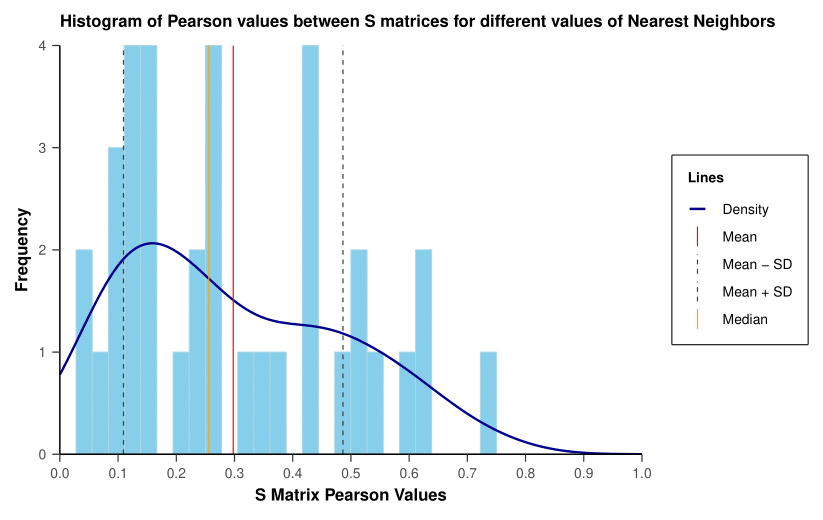

For $nn'$, we chose the optimal value based on two custom metrics we especially defined for this case where the optimal number of clusters is 2.

For all $nn'$, we calculated:

1. The sum of the **variance** and the **interquartile range (IQR)** for the upper-triangular values (excluding the diagonal) of each final fused affinity matrix as an indication of spread.
2. The sum of the **kurtosis** and **absolute skewness** (excluding the diagonal), as high skewness or kurtosis can indicate that the values are concentrated towards the tails, which might suggest better separation.
3. The min-max (rescaling to $[0,1]$) normalized (across matrices) values for each metric.
4. The matrix for which the sum of the two “min-max normalized” metrics is the highest, is chosen.

**Automatic conclusion:** Best similarity matrix based on combined normalized scores is for $nn' = 20$. We therefore proceed with $nn' = 20$.

# Main results on training data

## Multi-omics clustering

The M3C consensus $k$-means, results using the $t$-SNE embeddings produced by the $S$ matrix for $nn' = 20$, for $k = 2$ are shown below (pairwise distances heatmap):

[figure not shown]

The corresponding multi-omic heatmap is shown below:

[figure not shown]

The Ajusted Rand Index (ARI) and Normalized Mutual Information (NMI) values (when CIMLR subtypes are compared to the MOVICS consensus subtypes CS1, CS2) are:

**ARI:** 0.0022851 **NMI:** 0.0021663

The values are very low and indicate that CIMLR produces different clusters than consensus `MOVICS`.

## Clinical variables

With respect to clinical variables statistically significant associations were found between the subtypes and **vital status, history of neoadjuvant treatment, PR status, ER status, HER2 status (not confirmed in bar charts), ER and PR cell level percentages, and histological type**. Results can also be found in the summary file (Exact tests).

[figure not shown]

And just significant barcharts:

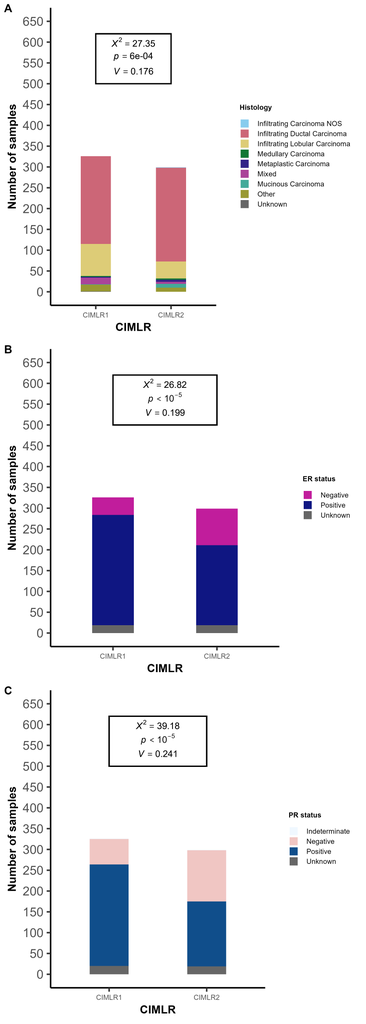

## Mutations

The MOVICS package provides a function `compMut()` which applies independent testing (i.e., Fisher’ s exact test or $\chi^2$ test) for each mutation, and generates a table with statistical results and creates an OncoPrint using those differentially mutated genes.

**Oncoprint:**

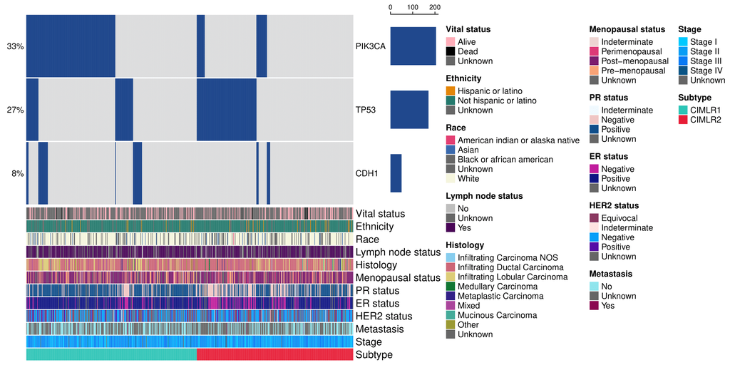

**Comparison with MOVICS consensus subtypes**:

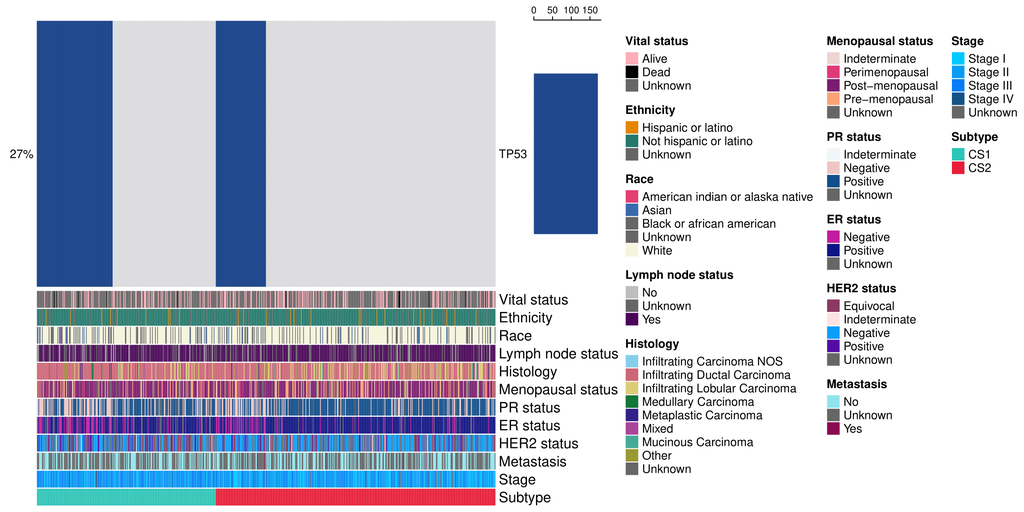

**Comparison with MOVICS CIMLR subtypes**:

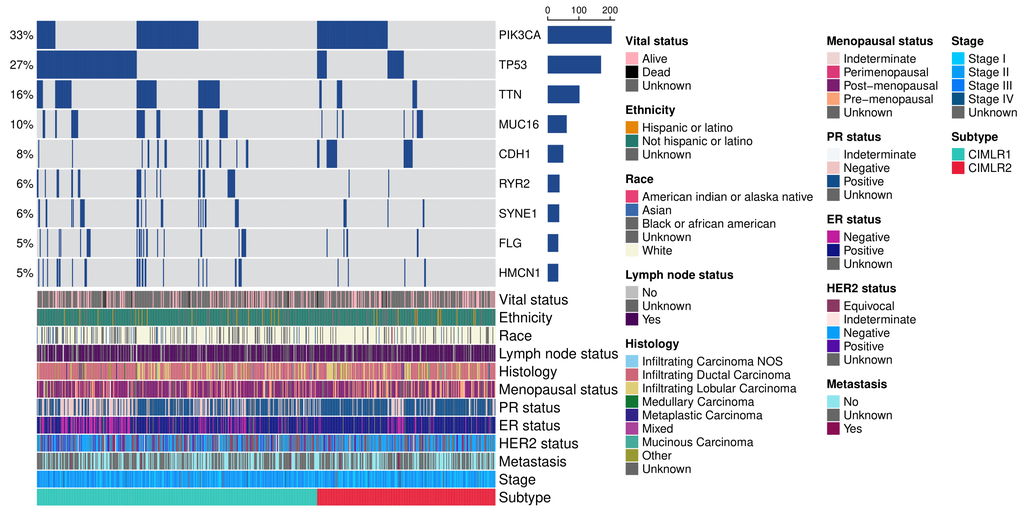

## Differential Gene Expression Analysis (DGEA)

DGEA is performed in order to compare the expression of the two identified consensus subtypes using the **limma** package.

In order to identify subtype-specific markers, we find the markers that are up-regulated in CIMLR1 vs. all other clusters and the ones which are down-regulated in CIMLR1 vs. all other clusters etc.

In this procedure, the most differentially expressed genes sorted by **log2FoldChange** are chosen as the biomarkers for each subtype (200 biomarkers for each subtype by default; Here we set 200 -> 100 markers). These biomarkers should pass the significance threshold (e.g., nominal $p-$value < 0.05 and adjusted $p-$value < 0.05) and must not overlap with any biomarkers identified for other subtypes.

**Up-regulated markers**

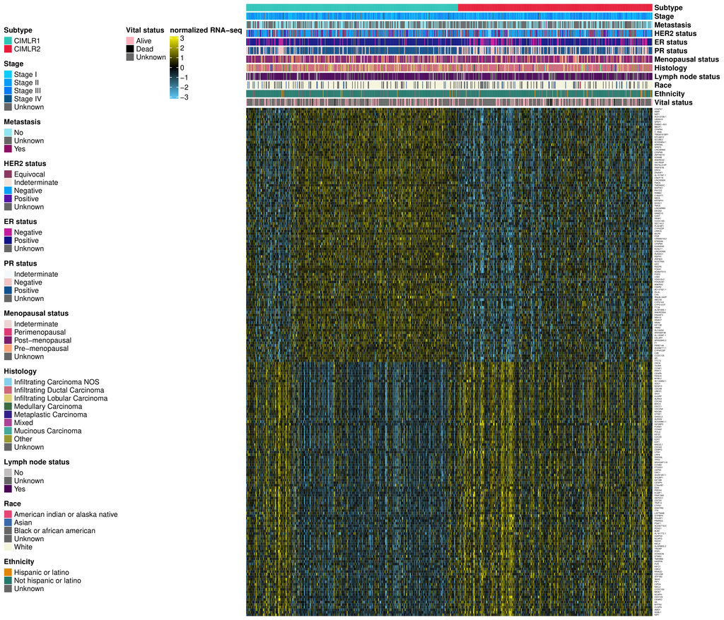

## Gene Set Enrichment Analysis

GSEA is carried out using a gene set background which includes all gene sets derived from GO biological processes (`Resources/Pathways/c5.go.bp.v2024.1.Hs.symbols.gmt`) from The Molecular Signatures Database (MSigDB, https://www.gsea-msigdb.org/gsea/msigdb/index.jsp).

Likewise, these identified specific pathways should pass the significance threshold (e.g., nominal $p-$value < 0.05 and adjusted $p-$value < 0.25; we set the latter to 0.1) and must not overlap with any pathways identified for other subtypes. After having the subtype-specific pathways, genes that are inside the pathways are retrieved to calculate a single sample enrichment score by using `GSVA` R package. Subsequently, subtype-specific enrichment score will be represented by the mean or median (mean by default) value within the subtype, and will be further visualized by diagonal heatmap.

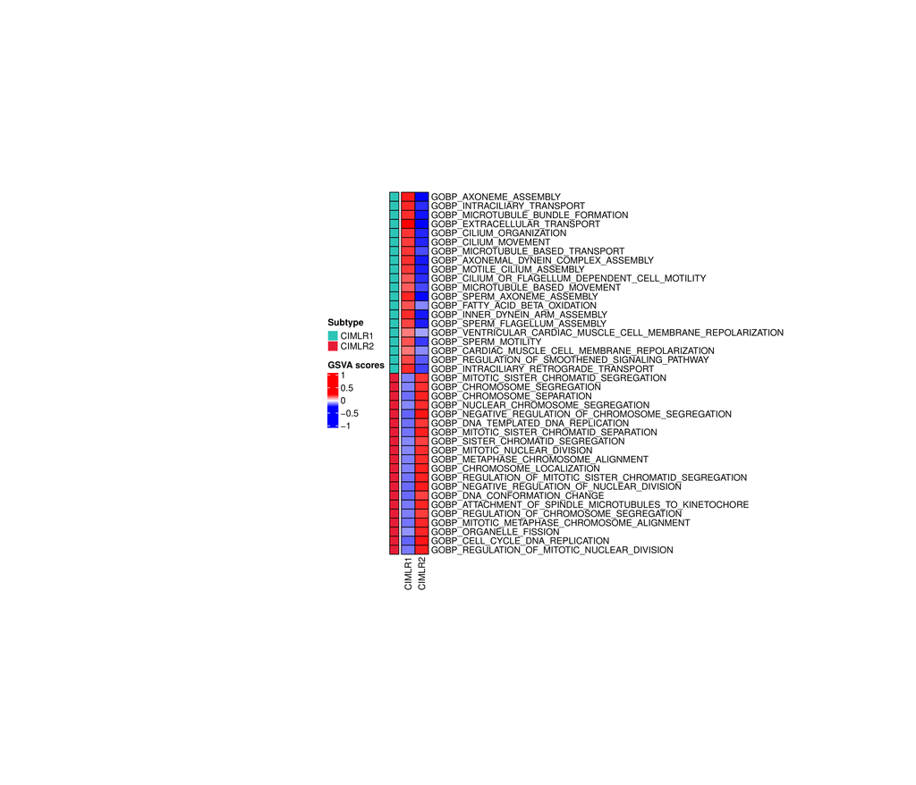

**Comparison with MOVICS consensus subtypes**:

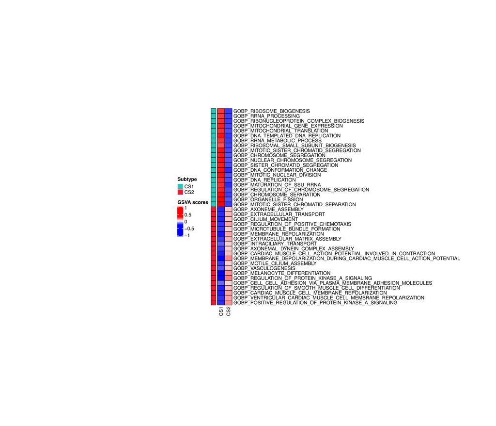

**Comparison with MOVICS CIMLR subtypes**:

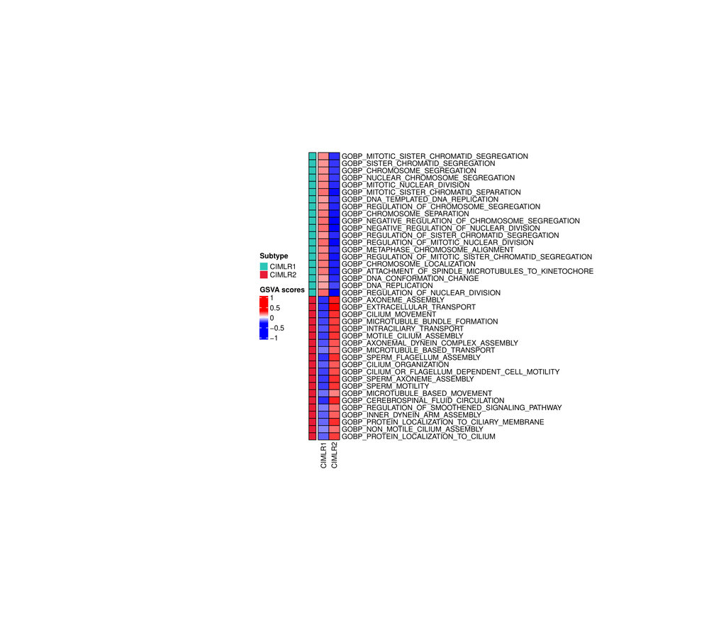

For all the new defined molecular subtypes, it is critical to depict its characteristics validated by different signatures of gene sets. MOVICS provides a simple function which uses gene set variation analysis to calculate an enrichment score for each sample in each subtype based on given gene set list of interest.

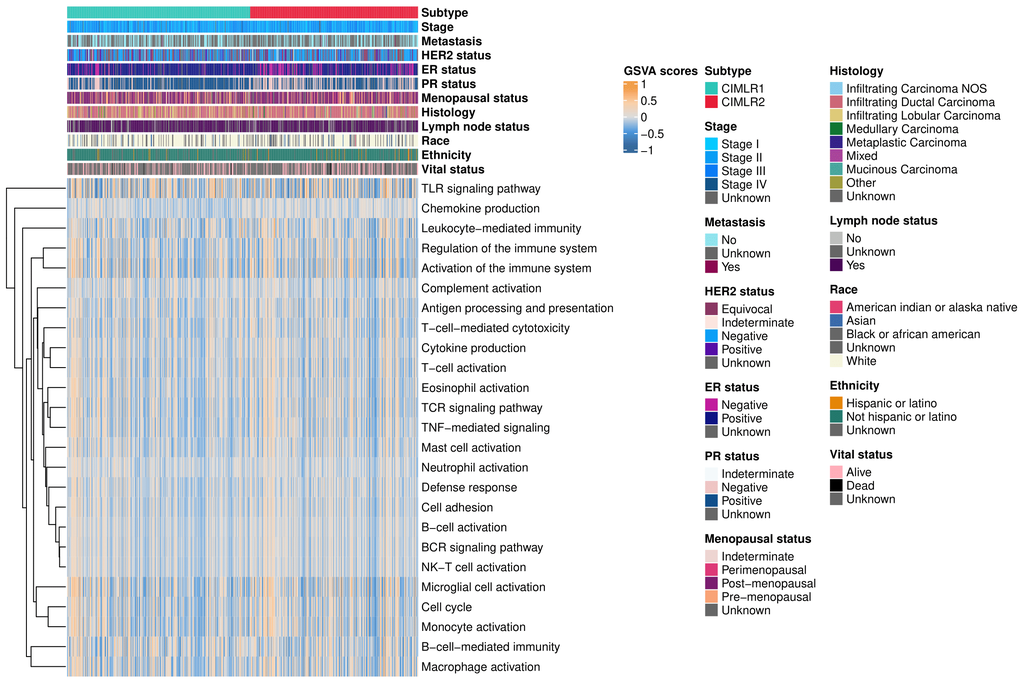

**Comparison with MOVICS consensus subtypes**:

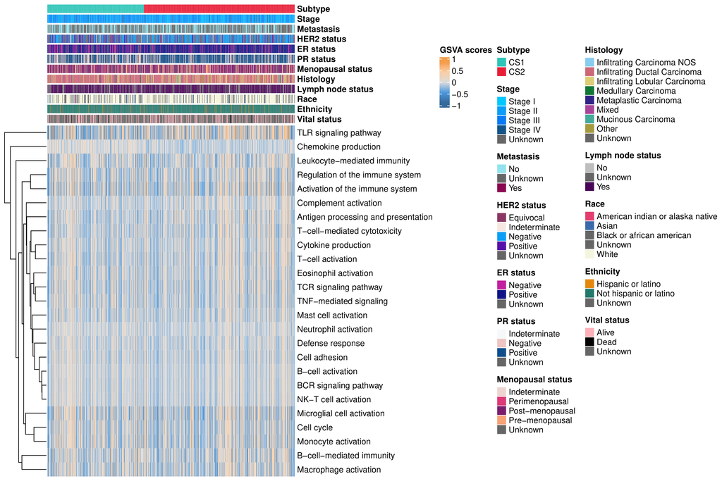

**Comparison with MOVICS CIMLR subtypes**:

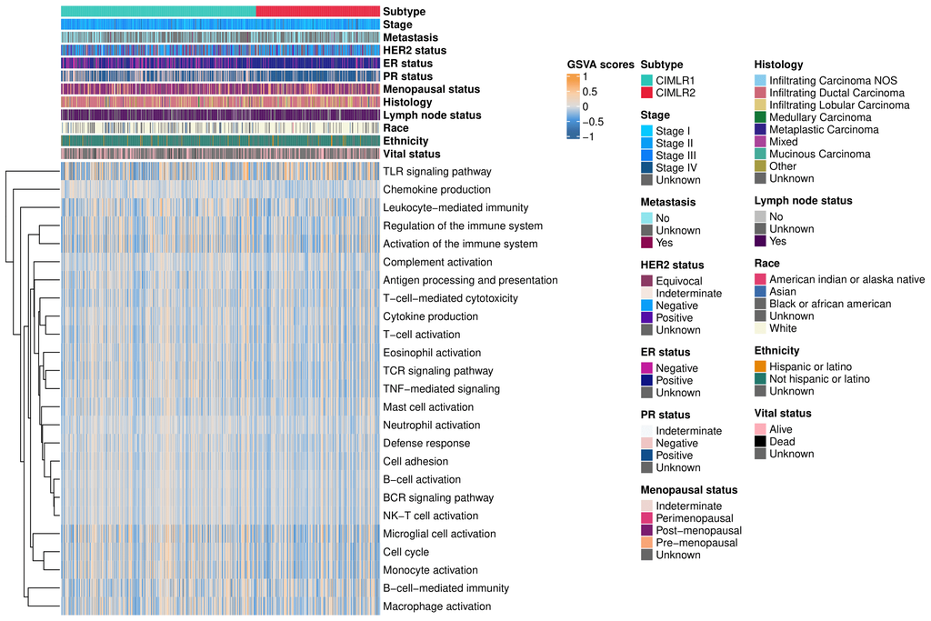

# Evaluation results

## Nearest Template Prediction (NTP)

MOVICS provides two model-free approaches for subtype prediction in validation cohort. First, MOVICS switches to nearest template prediction ([NTP](https://pubmed.ncbi.nlm.nih.gov/21124904/)) which can be flexibly applied to cross-platform, cross-species, and multiclass predictions without any optimization of analysis parameters.

Here cosine similarity is used to compare external samples to class templates (here we use the up-regulated genes in the form of a binary matrix with two columns: cluster 1 / cluster 2 where an entry is 1 if the gene is up-regulated in the cluster or -1 otherwise). The nearest class for each sample is determined by the smallest distance (converted from cosine similarity here). Each sample’s result includes the nearest class prediction, the distance to all templates, and the p-value of the prediction.

The function randomly permutes the sample labels multiple times (here `nPerm = 10000`) to generate a null distribution of similarity scores between samples and class templates. For each observed sample-to-template distance, the function compares it against the null distribution to calculate a $p$-value. This $p$-value indicates the likelihood that the observed match could have occurred by chance. The $p$-values are adjusted using the false discovery rate (FDR) method to control for multiple hypothesis testing, ensuring robust statistical inference.

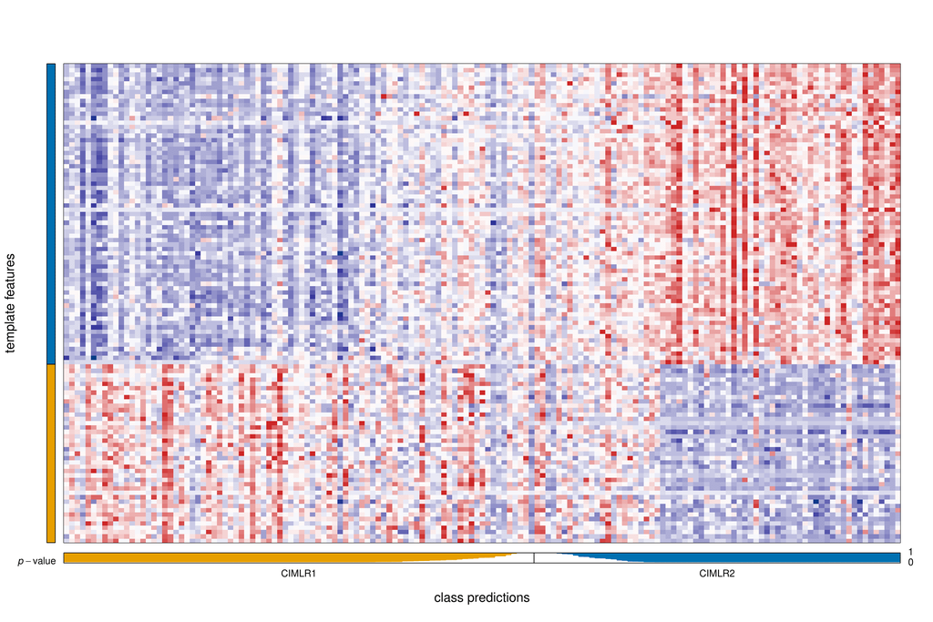

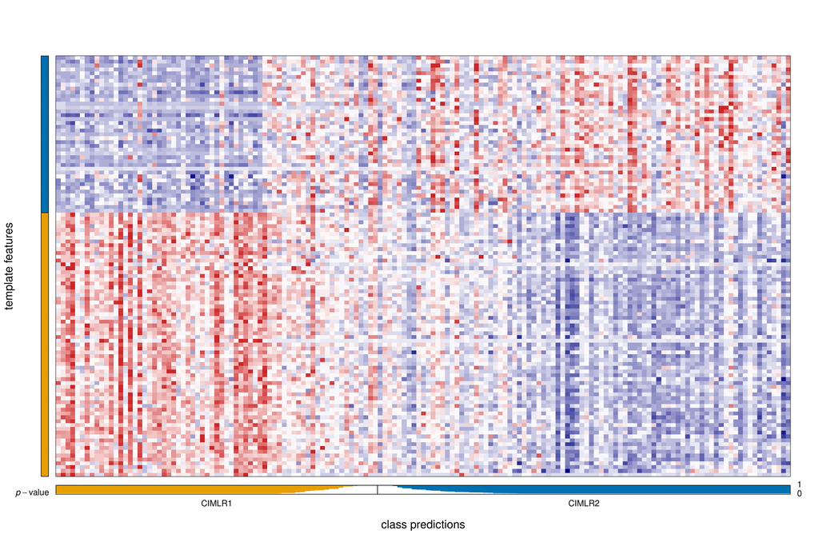

Results on the comparisons of transNEO clinical variables with respect to the predicted consensus subtypes are summarised in this file.

## Partition Around Medoids (PAM)

To be specific, `runPAM()` first trains a partition around medoids (PAM) classifier in the discovery (training) cohort (i.e., TCGA) to predict the subtype for patients in the external validation (testing) cohort (i.e., transNEO), and each sample in the validation cohort was assigned to a subtype label whose centroid had the highest Pearson correlation with the sample. Finally, the [in-group proportion (IGP)](https://pubmed.ncbi.nlm.nih.gov/16613834/) statistic (the proportion of samples within a cluster that were classified into the same cluster upon random permutation of the data) is estimated to evaluate the similarity and reproducibility of the acquired subtypes between discovery and validation cohorts (i.e. are the clusters identified in TCGA reproducible in transNEO after label permutation).

Compare CIMLR TCGA vs. PAM TCGA:

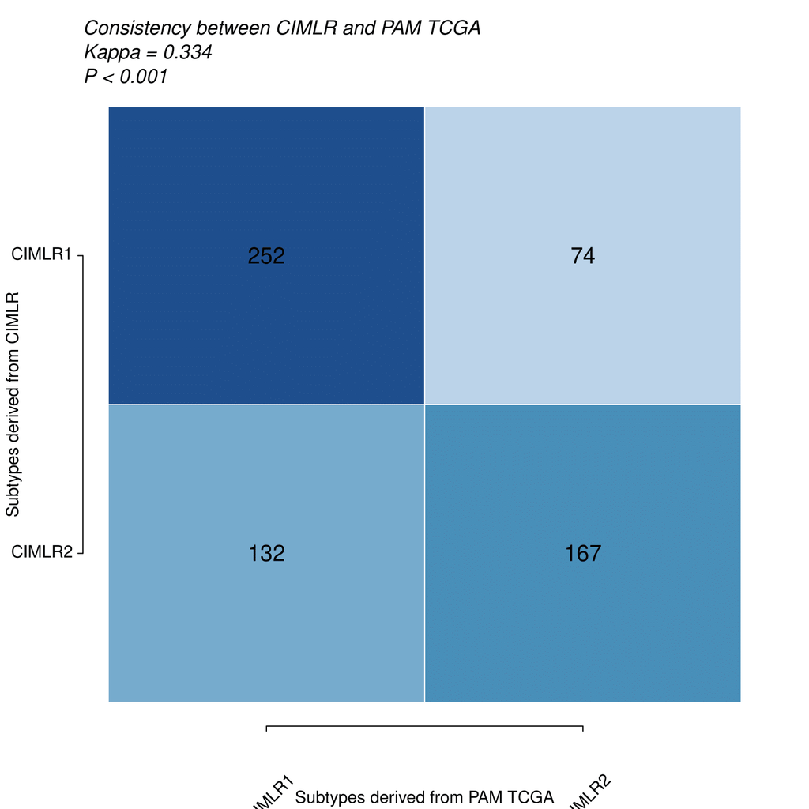

Compare CIMLR TCGA vs. NTP TCGA:

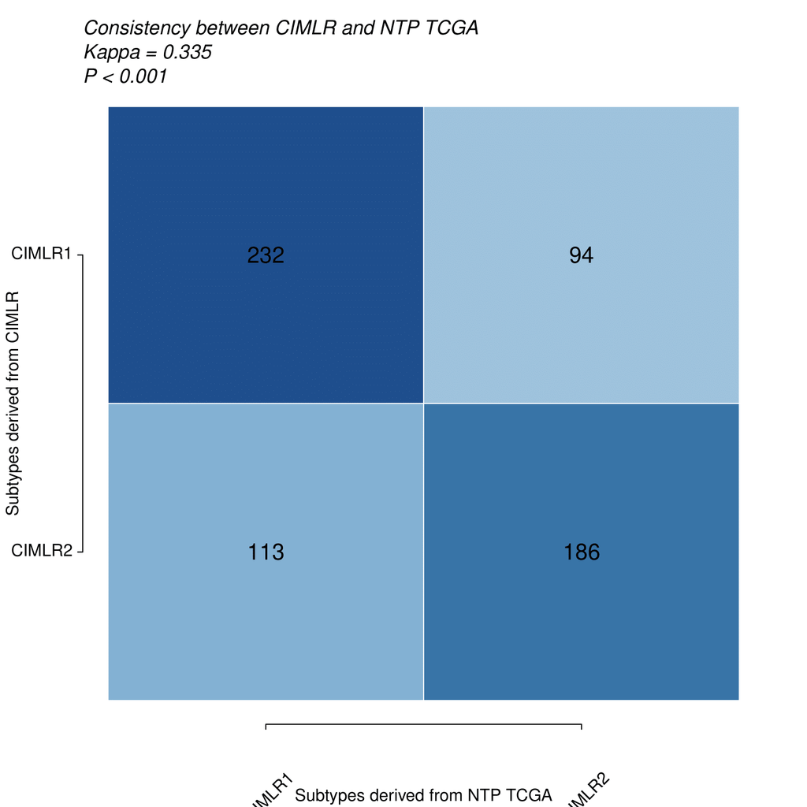

Compare NTP transNEO vs. PAM transNEO:

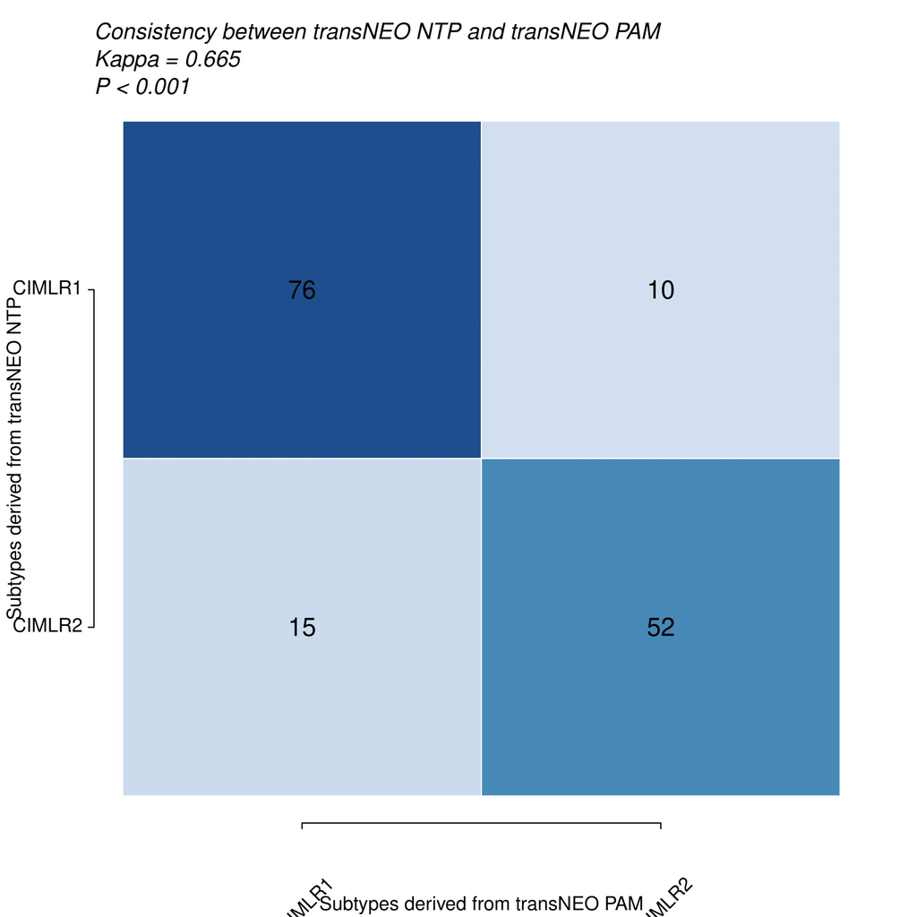

# Supplementary results

## PCA from final affinity matrices

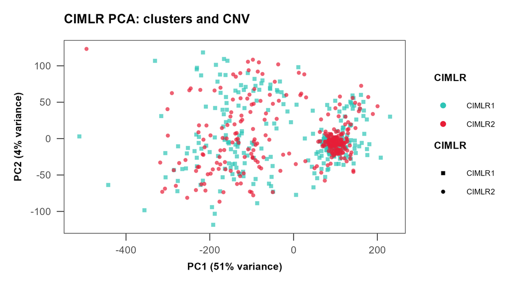

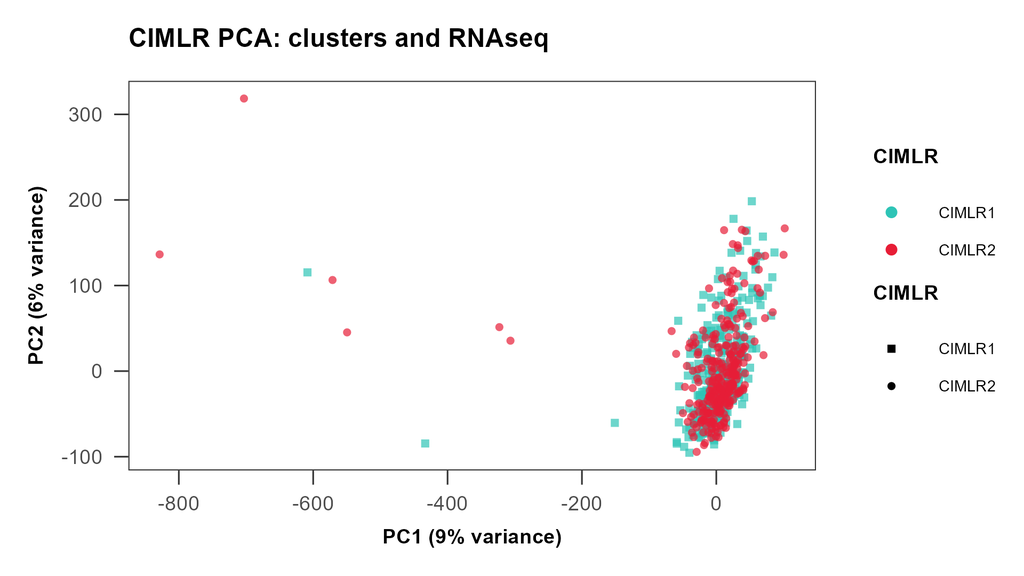

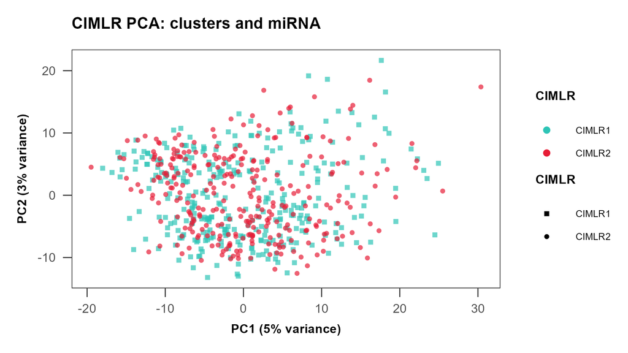

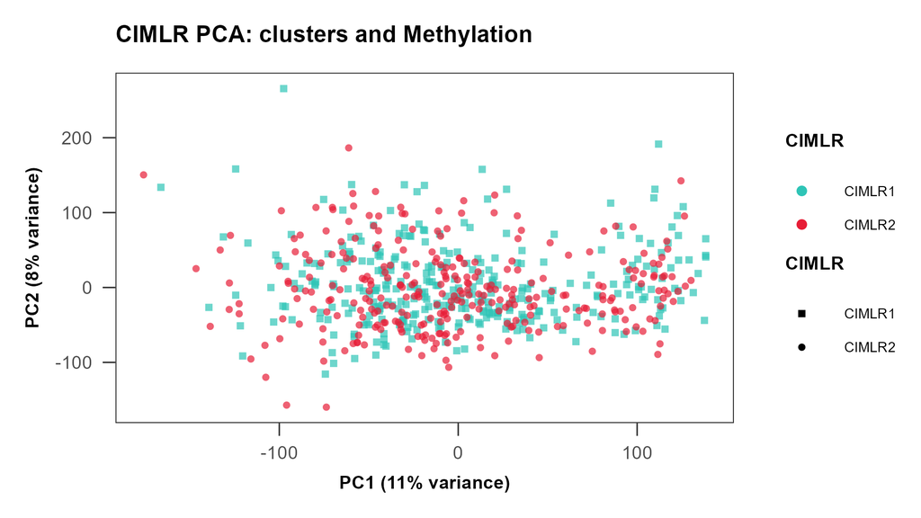

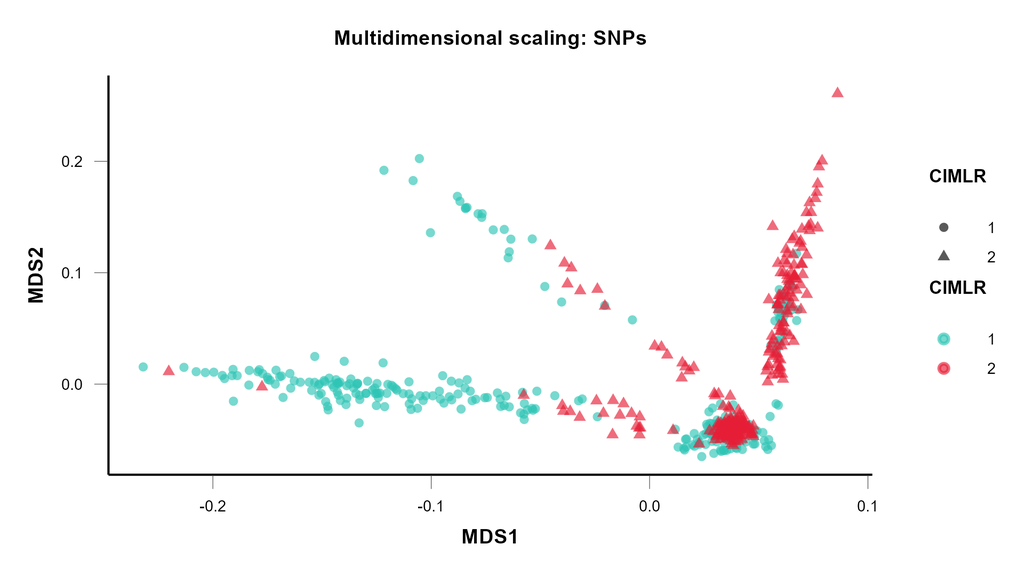

## Drug Sensitivity

We also perform a few drug sensitivity comparisons. MOVICS uses the pRRophetic package for prediction of clinical chemotherapeutic response from tumor gene expression levels (a pre-trained ridge regression model is fit for each gene and the $IC_{50}$ of each drug).

**Sorafenib**

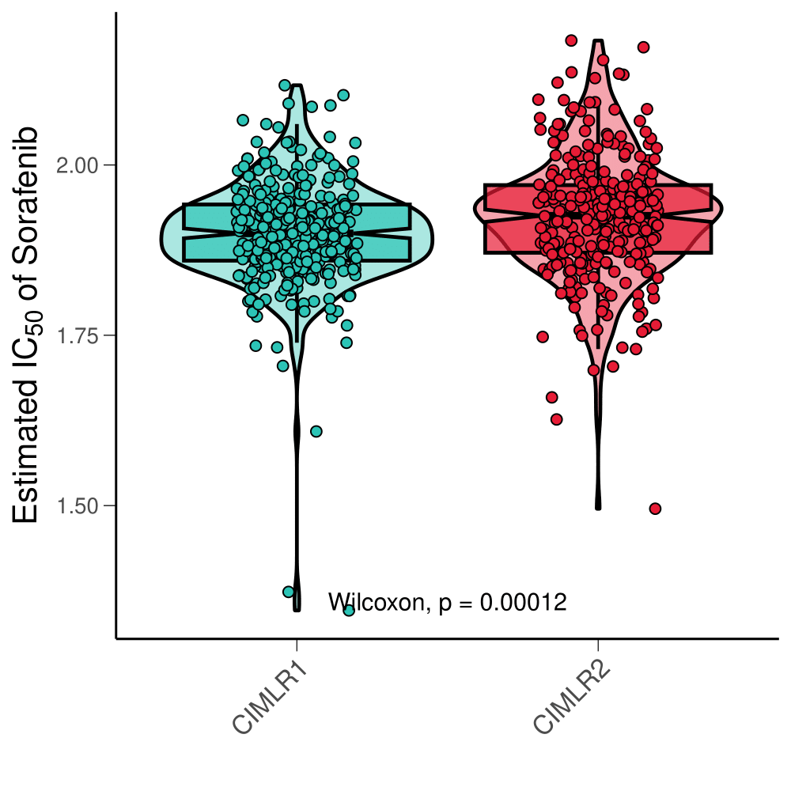

**Comparison with MOVICS consensus subtypes**:

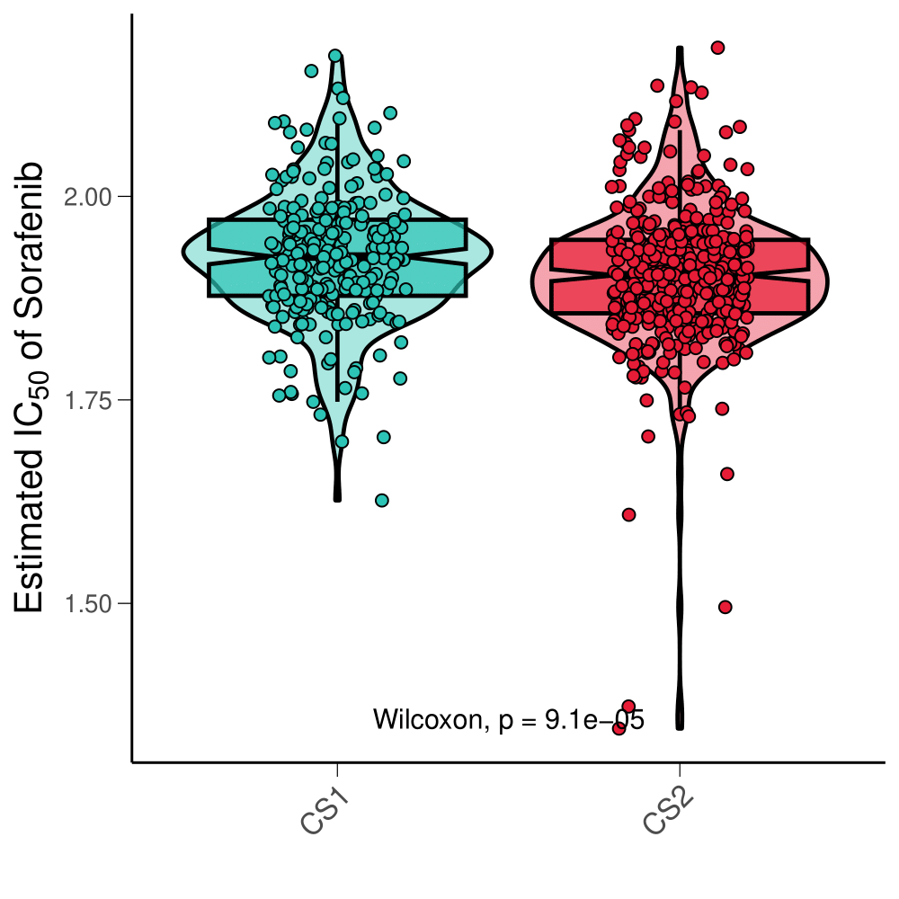

**Comparison with MOVICS CIMLR subtypes**:

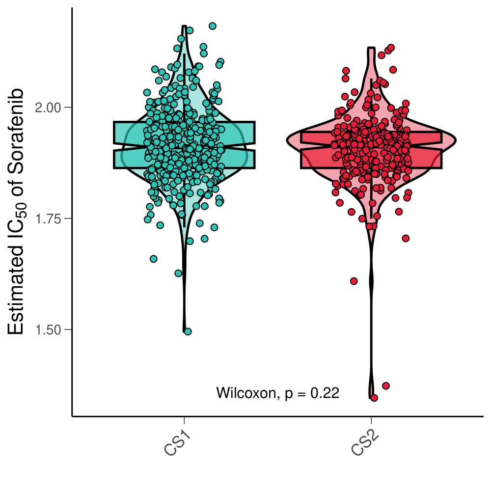

**Paclitaxel**

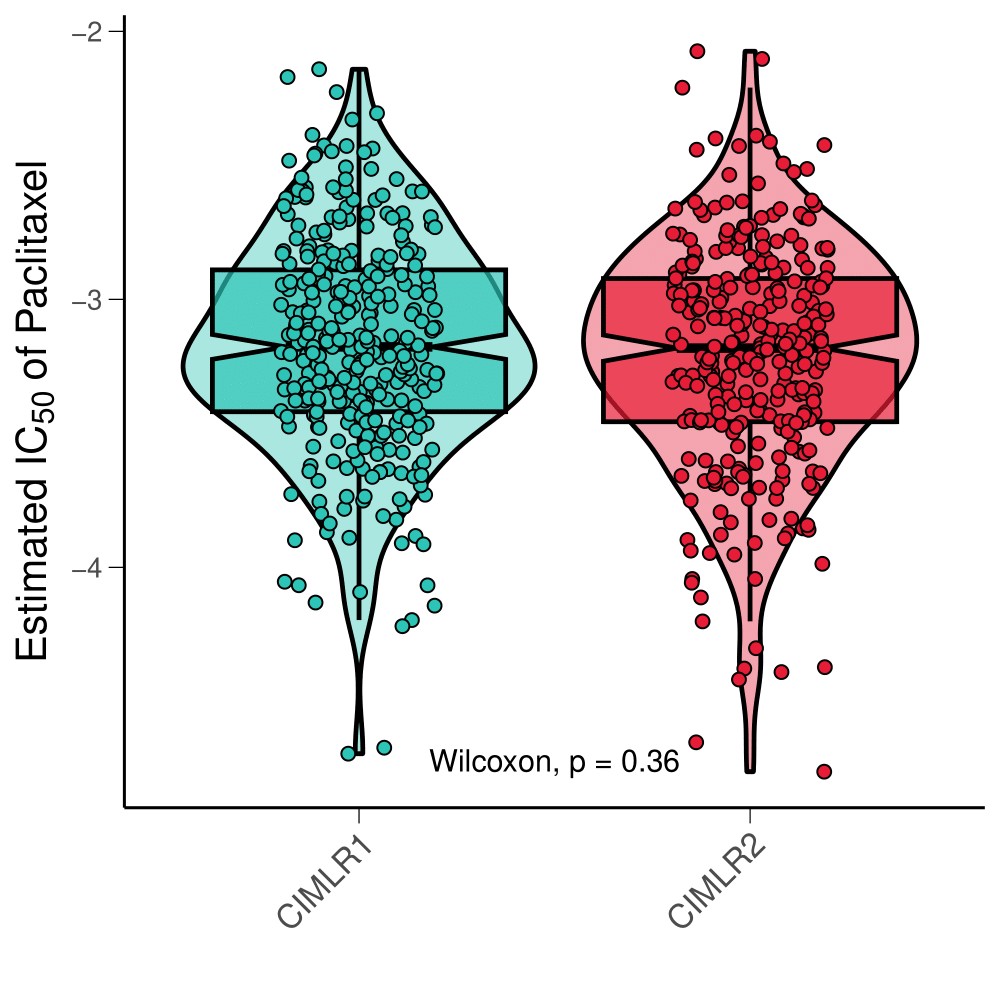

**Comparison with MOVICS consensus subtypes**:

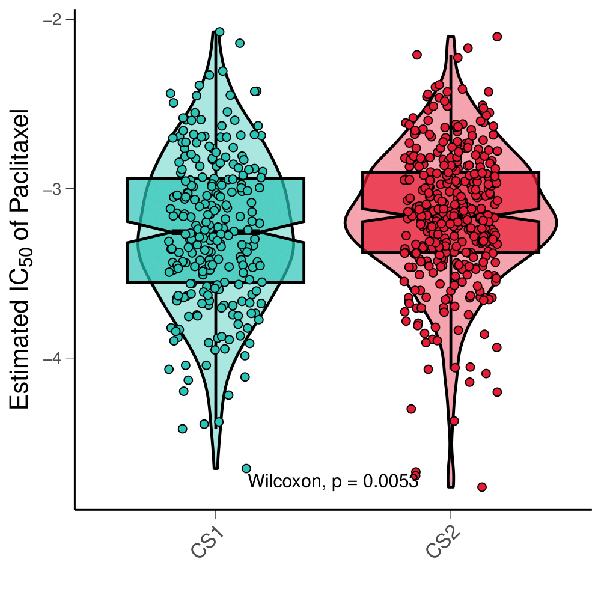

**Comparison with MOVICS CIMLR subtypes**:

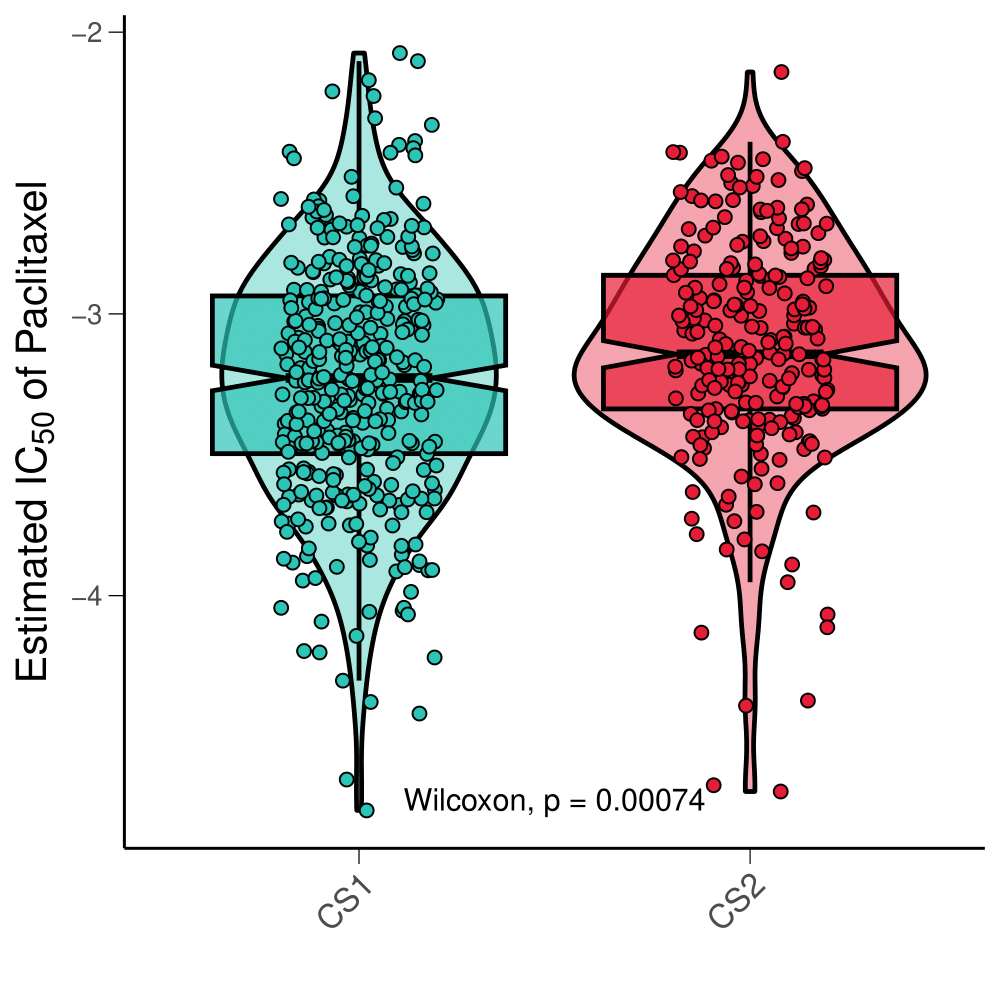

**Lapatinib**

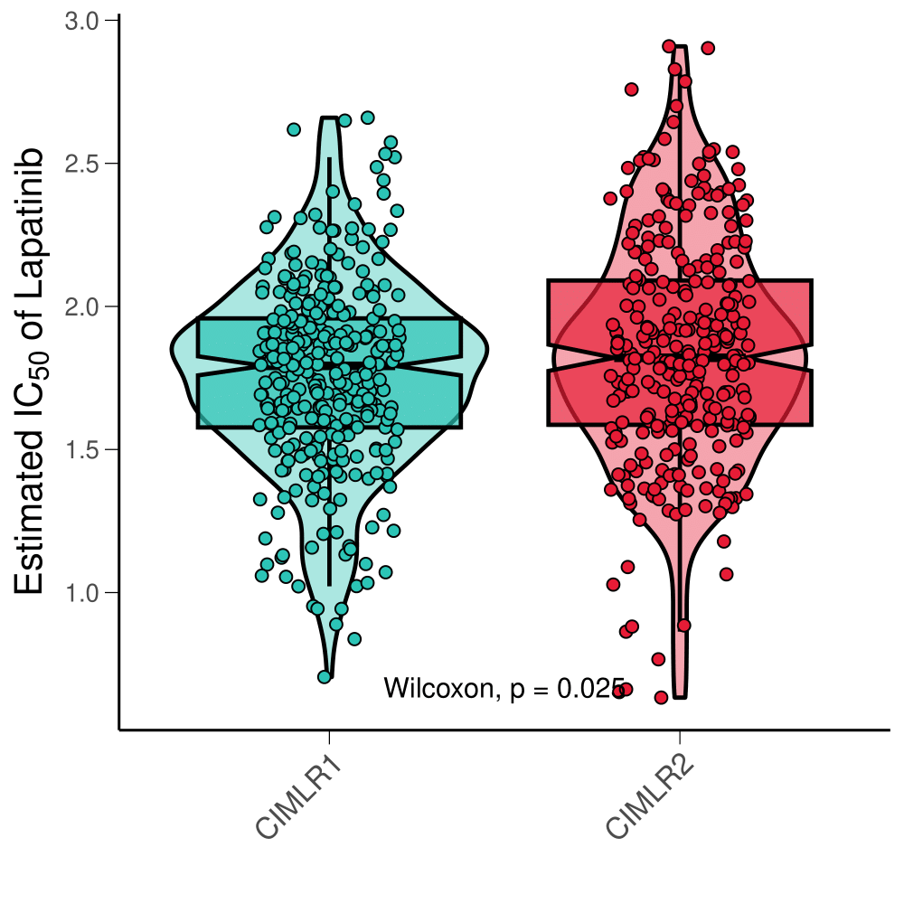

**Comparison with MOVICS consensus subtypes**:

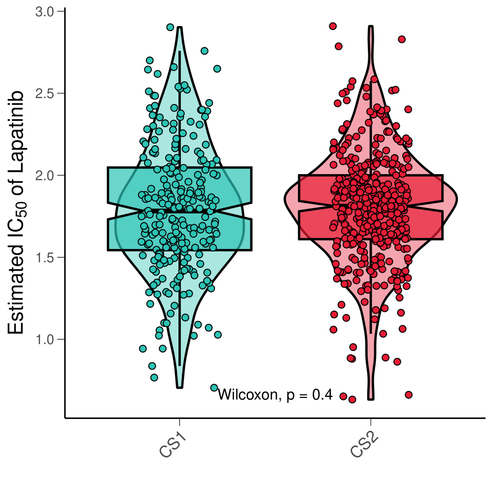

**Comparison with MOVICS CIMLR subtypes**:

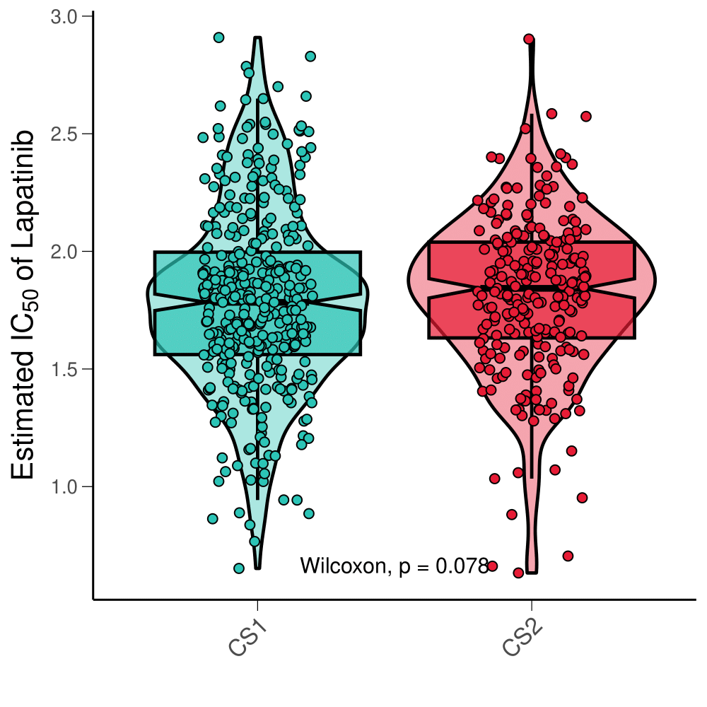

**Doxorubicin**